# Analysis LEZ

41783

25/02/2020

Basic configuration and loading of packages:

```r
# library(jsonlite)
library(tidyverse)
library(rvest)

library(sf) # Geo analysis
library("rgdal")

library(DBI) # SQL db

library(panelView)
library(lubridate)
```

## Index of contents

- Read data from pre-processing
  - Nuts regions geographies
  - data from capstone_db
    - nuts_time (outcomes, controls and mediators)
    - treatment from Umweltzonen
- Do explorative analysis on the volatility of outcomes
- Create variables of interest
- Do analysis

## Read data from pre-processing:

### Nuts Regions geographies

```r
# Characteristics of nuts3:

nuts.sf <- readRDS("data/nuts_sf_final")
nuts.sf <- nuts.sf %>%
  dplyr::rename(
    geo = NUTS_ID,
    nuts_level = LEVL_CODE,
    country = CNTR_CODE,
    nuts_name = NUTS_NAME,
    # min_time_gz = min_time
  ) # Create a "never treated" and "always treated" variable
  # mutate(
  #   appl_never = ifelse(appl_uar == 0 & appl_gz == 0, 1, 0),
  #   appl_sure = appl_uar*appl_gz,
  #   min_year_gz = as.character(min_time_gz) %>%
  #          substr(1,4) %>% as.numeric() # year
  # )

nuts.sf %>% as.data.frame() %>% head()
```

|  | nuts_level | geo | country | nuts_name | geometry | with_uar_point | with_uar_50km | with_uar_100km | with_gzones_point | with_gzones_50km | with_gzones_100km | with_umweltzonen_point | with_umweltzonen_50km | with_umweltzonen_100km | treated_osm | treated_uar | treated_gz | treated_uz | treated_any | contr_restr_point | contr_restr_50km | contr_restr_100km | urb_index |
| --- | --- | --- | --- | --- | --- | --- | --- | --- | --- | --- | --- | --- | --- | --- | --- | --- | --- | --- | --- | --- | --- | --- | --- |
| 1 | 3 | HR043 | HR | Krapinsko-zagorska županija |  | FALSE | FALSE | TRUE | FALSE | FALSE | TRUE | FALSE | FALSE | FALSE | FALSE | FALSE | FALSE | FALSE | FALSE | TRUE | TRUE | FALSE | 2.884615 |
| 2 | 2 | CH02 | CH | Espace Mittelland |  | TRUE | TRUE | TRUE | FALSE | FALSE | TRUE | FALSE | FALSE | TRUE | FALSE | FALSE | FALSE | FALSE | FALSE | FALSE | FALSE | FALSE | 2.661166 |
| 3 | 2 | CH03 | CH | Nordwestschweiz |  | FALSE | TRUE | TRUE | FALSE | TRUE | TRUE | FALSE | TRUE | TRUE | FALSE | FALSE | FALSE | FALSE | FALSE | TRUE | FALSE | FALSE | 2.313433 |
| 4 | 2 | AL02 | AL | Qender |  | FALSE | FALSE | FALSE | FALSE | FALSE | FALSE | FALSE | FALSE | FALSE | FALSE | FALSE | FALSE | FALSE | FALSE | TRUE | TRUE | TRUE | 2.333333 |
| 5 | 2 | AL03 | AL | Jug |  | FALSE | FALSE | TRUE | FALSE | FALSE | FALSE | FALSE | FALSE | FALSE | FALSE | FALSE | FALSE | FALSE | FALSE | TRUE | TRUE | FALSE | 2.800000 |
| 6 | 2 | BG33 | BG |  |  | FALSE | FALSE | FALSE | FALSE | FALSE | FALSE | FALSE | FALSE | FALSE | FALSE | FALSE | FALSE | FALSE | FALSE | TRUE | TRUE | TRUE | 2.972940 |

### Get data from SQLdb:

```r
db <- dbConnect(RSQLite::SQLite(), "data/capstonedb")
dbListTables(db)
```

```
[1] "airq_plans"   "nuts3"        "nuts_time"    "umweltezonen" "umweltzonen"
```

Tables:

- airq_plans: List of (new) air quality plans
- nuts3: NUTS code, name and attainment status according to UAR and GZ, and minimum year for GZ
- umweltzonen: Treatment status of all zones in germany for each status with timing.
- nuts_time statistical data on NUTS regions (outcomes and controls)

#### Get nuts_time (outcomes, mediators and controls)

```r
dta %>% names()
```

```
  [1] "geo"               "time"
  [3] "pop_total"         "pop_unk_age"
  [5] "pop_15_64"         "pop_65plus"
  [7] "pop_less15"        "gdp_eur_hab"
  [9] "gdp_mio_pps"       "gdp_mio_eur"
 [11] "empl_O-Q"          "empl_J"
 [13] "empl_A"            "empl_M_N"
 [15] "empl_L"            "empl_K"
 [17] "empl_F"            "empl_B-E"
 [19] "empl_O-U"          "empl_G-I"
 [21] "empl_G-J"          "empl_TOTAL"
 [23] "empl_K-N"          "empl_C"
 [25] "empl_R-U"          "gva_C"
 [27] "gva_O_U"           "gva_A"
 [29] "gva_K"             "gva_F"
```

[output cut: 53 more lines]

Create variables of interest (outcomes and controls) (and possibly a restricted dataset only with those)

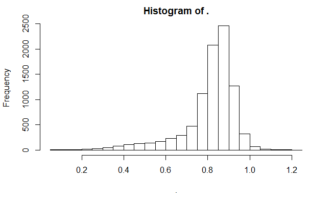

```r
## (for NUTS2)

### outcomes:

# hours worked per person (abseentism/temporality)
# (waiting to get data on hours)

temp <- dta %>%
  # dplyr::group_by(geo) %>% # 1000's hours/1000's employees
  mutate(hours_per_worker = hours_TOTAL/empl_TOTAL,
         hours_per_day = hours_per_worker/259) #approx

# Looks like correct
# temp %>%
#   ggplot() +
#   geom_histogram(aes(x = hours_per_day))

# wages per worker
# (waiting to get data on wages)

temp <- temp %>%
  # dplyr::group_by(geo) %>%
  mutate(wages_per_worker =
           (wages_TOTAL*1000000)/(empl_TOTAL*1000),
         wage_per_day = wages_per_worker/259) #approx

# # Looks like correct
# temp %>%
#   ggplot() +
#   geom_density(aes(x = wage_per_day))
# # +  facet_wrap(facets = vars(time))

# wage/hour worked (productivity?)

temp <- temp %>%
  # dplyr::group_by(geo) %>%
  mutate(wage_per_hour =
           (wages_TOTAL*1000000)/(hours_TOTAL*1000)) #approx

# # Looks like correct
# temp %>%
#   ggplot() +
#   geom_density(aes(x = wage_per_hour))
# # +  facet_wrap(facets = vars(time))

# Unemployment
# (done)

# Employment rate (with respect to active pop or "wotking age pop")

temp <- temp %>%
  # dplyr::group_by(geo) %>%
  mutate(empl_rate_active = # both in thousands
           (empl_TOTAL*1000)/(active_T_Y_GE15*1000),
         empl_rate_wpop = # both in thousands
           (empl_TOTAL*1000)/pop_15_64)

## Some doubts left...
# temp$empl_rate_active %>% hist(breaks = 30) # Why above 1?
# temp$empl_rate_wpop %>% hist(breaks = 30)

 ### Controls:

# Investment/capita (nuts 2)
# Educational level/capita (nuts 2)
# Dependency ratio (NUTS 2)

# Share of Women in the labor market
temp <- temp %>%
  # dplyr::group_by(geo) %>%
  mutate(active_F_share = # both in thousands
           `active_F_Y15-64`/`active_M_Y15-64`)

temp$active_F_share %>% hist(breaks = 30)
```

```r
## (for NUTS 3)

### Outcomes:

# Proportion of working age population

# Dependency rate

### Controls
# mean age
# mortality and birth rate

dta %>% names()
```

```
  [1] "geo"               "time"
  [3] "pop_total"         "pop_unk_age"
  [5] "pop_15_64"         "pop_65plus"
  [7] "pop_less15"        "gdp_eur_hab"
  [9] "gdp_mio_pps"       "gdp_mio_eur"
 [11] "empl_O-Q"          "empl_J"
 [13] "empl_A"            "empl_M_N"
 [15] "empl_L"            "empl_K"
 [17] "empl_F"            "empl_B-E"
 [19] "empl_O-U"          "empl_G-I"
 [21] "empl_G-J"          "empl_TOTAL"
 [23] "empl_K-N"          "empl_C"
 [25] "empl_R-U"          "gva_C"
 [27] "gva_O_U"           "gva_A"
 [29] "gva_K"             "gva_F"
```

[output cut: 53 more lines]

```r
 # others to do GDP and Productivity: GDP/capita, Investment/capita, wage levels,
```

#### Get treatment from umweltzonen

[output not shown]

### Small analysis of the volatility of data:

```r
get_volatility <- function(data = dta,
                           CNTR_CODE = "DE",
                           time_vector = 2000:2019,
                           variable = "gdp_eur_hab",
                           cluster_differences = "nuts1" # can be "country"
){
  temp <- data %>%
    arrange(geo, time) %>%
    dplyr::mutate(nuts1 = substr(geo, 3, 4),
           country = substr(geo, 1, 2)) %>%
    filter(
      country == CNTR_CODE,
      # !is.element(time, c(2008, 2009, 2010, 2011)),
    ) %>%
    dplyr::group_by(geo) %>%
    dplyr::mutate(perc_change_unit = (eval(parse(text=variable))-lag(eval(parse(text=variable))))/lag(eval(parse(text=variable)))*100) %>%
    ungroup() %>%
    dplyr::group_by("nuts1", time) %>%
    dplyr::mutate(mean_change_group = mean(perc_change_unit, na.rm = TRUE),
           perc_change_dev = perc_change_unit - mean_change_group) %>%
    ungroup() %>%
    select(geo, time, variable, mean_change_group, perc_change_unit, perc_change_dev)
  print(temp %>% summary)
  return(temp)
}
```

```r
temp <- get_volatility(data = temp, CNTR_CODE = "DE",
                       time_vector = 2000:2019,
                       variable = "unempR_T")
```

```
Note: Using an external vector in selections is ambiguous.
i Use `all_of(variable)` instead of `variable` to silence this message.
i See <https://tidyselect.r-lib.org/reference/faq-external-vector.html>.
```

```
     geo                 time         unempR_T
 Length:8891        Min.   :1990   Min.   : 1.800
 Class :character   1st Qu.:2005   1st Qu.: 4.300
 Mode  :character   Median :2010   Median : 6.300
                    Mean   :2010   Mean   : 7.321
                    3rd Qu.:2015   3rd Qu.: 8.700
                    Max.   :2019   Max.   :22.400
                                   NA's   :7874
 mean_change_group perc_change_unit  perc_change_dev
 Min.   :-16.542   Min.   :-34.146   Min.   :-26.906
 1st Qu.: -9.624   1st Qu.:-12.102   1st Qu.: -5.186
 Median : -7.338   Median : -5.826   Median : -0.254
 Mean   : -3.641   Mean   : -3.570   Mean   :  0.000
 3rd Qu.:  5.102   3rd Qu.:  3.659   3rd Qu.:  4.420
 Max.   : 17.938   Max.   : 47.059   Max.   : 38.846
 NA's   :894       NA's   :7929      NA's   :7929
```

### Small analysis of the volatility of the GDP data:

For the whole dataset:

[figure not shown]

For german cities

```r
# gdp_wide2 <- gdp_wide %>%
#   select(-geo)
# rownames(gdp_wide2) <- gdp_wide$geo
# gdp_wide2 <- as.data.frame(t(gdp_wide2)) %>%
#   mutate(year = rownames(t(gdp_wide2))) %>%
#   arrange(year)

gdp_de <- gdp %>% filter(substr(geo, 1,2) == "DE")

deviations_ger <- gdp_de %>%
  select(gdp_eur_hab, geo, time) %>%
  # filter(!is.element(time,c(2008, 2009, 2010, 2011))) %>%
  mutate(nuts1 = substr(geo, 3, 4),
         country = substr(geo, 1, 2)) %>%
  group_by(geo) %>%
  mutate(perc_change = (gdp_eur_hab/lag(gdp_eur_hab)-1)*100) %>%
  ungroup() %>%
  group_by(nuts1, time) %>%
  mutate(mean_change = mean(perc_change, na.rm = TRUE),
         perc_change_dev = perc_change - mean_change)

deviations_ger$perc_change_dev %>% hist(breaks = 100, xlim = c(-10,10))
deviations_ger$perc_change_dev %>% summary()
deviations_ger
```

```r
ggplot(data = deviations_ger,
       aes(x = time, y = perc_change_dev, fill = geo, colour = nuts1)) +
           geom_line(alpha = 0.1) +
  guides(fill = FALSE) +
  # theme(legend.position = "none") +
  ylim(-15, +15)

# gdp_de_avg <- gdp_de
# wnF=arima(g, order=c(1,0,0),
#           seasonal = ,
#           xreg = ,)
# wnF$residuals
```

For London boroughs

```r
london_boroughs <- c(paste0("UKI", seq(31,45))) # UKI31 - UKI45

# How much lonfong borougs gdp varies year to year
gdp_london_boroughs <- gdp %>%
  select(gdp_eur_hab, geo, time) %>%
  filter(geo %in% london_boroughs) %>%
  group_by(geo) %>%
  mutate(perc_change = (gdp_eur_hab/lag(gdp_eur_hab)-1)*100) %>%
  filter(time > 2000 & time < 2017)

ggplot(data = gdp_london_boroughs, aes(x = time, y = perc_change, colour = geo)) +
  geom_line()

# How does the whole NUTS3 regions gdp varie?
mean_gdp_change <- gdp %>%
  select(gdp_eur_hab, geo, time) %>%
  group_by(geo) %>%
  mutate(perc_change = (gdp_eur_hab/lag(gdp_eur_hab)-1)*100) %>%
  ungroup() %>%
  # dplyr::group_by(time) %>%
  summarise(mean_perc_change = mean(perc_change, na.rm = TRUE))
  # filter(time > 2000,
  #        time < 2017)
mean_gdp_change

# What is the difference between both? (a higher bound of london's unit specific factors volatility - Would be better with only cities)

gdp_london_boroughs %>%
  left_join(mean_gdp_change) %>%
  mutate(clean_change = perc_change - mean_perc_change) %>%
  group_by(time) %>%
  summarise(mean_diff_change = mean(clean_change, na.rm = TRUE))
```

### Small analysis of the application of LEZ zones in Germany:

```r
umweltzonen <- dbGetQuery(db, "SELECT * from umweltzonen")
umweltzonen %>% head()
```

|  | State | LEZ | simple_LEZ | Status | Stage_1 | Stage_2 | Stage_3 | Announcment |
| --- | --- | --- | --- | --- | --- | --- | --- | --- |
| 1 | Nordrhein-Westfalen | Aachen | Aachen | Stufe 3 | 01.02.2016 | 01.02.2016 | 01.02.2016 | 2015-10-20 |
| 2 | Bayern | Augsburg | Augsburg | Stufe 3 | 01.07.2009 | 01.01.2011 | 01.06.2016 | NA |
| 3 | Baden-Württemberg | Balingen | Balingen | Stufe 3 | 01.04.2017 | 01.04.2017 | 01.04.2017 | NA |
| 4 | Berlin | Berlin | Berlin | Stufe 3 | 01.01.2008 | 01.01.2010 | 01.01.2010 | 2007-03-20 |
| 5 | Nordrhein-Westfalen | Bonn | Bonn | Stufe 3 | 01.01.2010 | 01.07.2012 | 01.07.2014 | 2009-10-01 |
| 6 | Bremen | Bremen | Bremen Mitte | Stufe 3 | 01.01.2009 | 01.01.2010 | 01.07.2011 | 2006-08-01 |

```r
umweltzonen %>% dim()
```

```
[1] 58  8
```

```r
um <- umweltzonen %>%
  mutate(Stage_1 = as.Date(Stage_1, "%d.%m.%Y"),
         Stage_2 = as.Date(Stage_2, "%d.%m.%Y"),
         Stage_3 = as.Date(Stage_3, "%d.%m.%Y"),
         Announcment = as.Date(Announcment))

all <- expand.grid(LEZ = um$LEZ,
                   year = seq(2007, 2017),
                   month = seq(01, 12),
                   # month = c("01", "02", "03", "04", "05", "06",
                   #          "07", "08", "09", "10", "11", "12"),
                   stringsAsFactors = FALSE)

panel_zones <- all %>%
  left_join(um) %>%
  mutate(date = as.POSIXct(paste0(year,"-", month, "-01" )),
         # LEZ = substr(LEZ, 1, 24),
         LEZ = sub(" *\\(.*", "", LEZ), # Everything until a "("
         # If i don't have the date of announcemnt I do as if there were none
         Announcment = if_else(is.na(Announcment), Stage_1, Announcment),

         status = case_when(
           date <= Announcment ~ 0, # not applied
           date <= Stage_1 ~ 1, # announced
           date <= Stage_2 ~ 2, # stage 1
           # If they don't have a stage 2 then they stayed in 1
           is.na(Stage_2) ~ 2,
           date <= Stage_3 ~ 3, #stage 2
           is.na(Stage_3) ~ 3,
           date > Stage_3 ~ 4, #stage 3
           # is.na(Announcment) ~ 0,
           # date < Stage_1
           TRUE ~ 0
         )
         # status = if_else(date < Announcment, 0, missing = 0,
         #                 if_else(date < Stage_1, 1,
         #                         if_else(date < Stage_2, 2,
         #                                 if_else(date < Stage_3, 3, 4,
         #                                         missing = 3))))
         # date_factor = paste0(year(date), "-", ifelse(
         #   month(date)<9, paste0("0", month(date)), month(date))),
         ) %>%
  arrange(Stage_3) %>%
  arrange(Stage_2) %>%
  arrange(Stage_1) %>%
  arrange(Announcment) %>%
  mutate(LEZ_factor = fct_inorder(LEZ)) %>%
  select(LEZ, date, status, year, month, LEZ_factor)

panel_zones %>% head()
```

```r
# png(filename = "images/LEZ application germany_2.png",
    # width = 750, height = 1000, res = 100)
panelView(month ~ status, data = panel_zones,
          index = c("LEZ_factor", "date"),
          by.timing = TRUE,
          axis.lab.gap = c(23,0),
          # axis.lab = "time",
          background = "white",
          main = "",
          xlab = "", ylab = "",
          na.rm = FALSE,
          pre.post = TRUE,
          legend.labs = c("No LEZ applied", "LEZ announced",
                          "Red, yellow or green sticker",
                          "Only yellow or green sticker", "Only green stiker"),
          color = c("grey90", "grey60", "red1", "yellow1", "green4")) +
  # Black vertical segments (+.5 because the graph starts at 1)
  geom_segment(x = 33.5, xend = 33.5, y = 2.5, yend = 32.5, size = 1.5) +
  # geom_segment(x = 12*10, xend = 12*10, y = 4.5, yend = 32.5, size = 1.5)
  # geom_vline(xintercept = 33, size = 2) +
  # geom_vline(xintercept = 12*10, size = 1.5)

  # White shading areas
  # annotate("rect", xmin = 0, xmax=Inf, ymin=32.5, ymax=Inf,
  #                             alpha = 0.6, fill='white') +
  # annotate("rect", xmin = 0, xmax=Inf, ymin=0.5, ymax=4.5,
  #                             alpha = 0.6, fill='white') +
  annotate("rect", xmin = 1, xmax=Inf, ymin=2.5, ymax=32.5,
           alpha = 0.6, color = "red",
           fill = NA, size = 1.5)
# dev.off()

# devtools::install_github('xuyiqing/panelView')
# RColorBrewer::brewer.pal.info
```

> NOTE! I NEED TO FIND THE DATE OF ANOUNCEMT OF THE MISSING LEZ!

(Image saved in png file)

### I need to exclude some other zones in the control pool with respect to geographical closeness:

- Those immediatly connected
- “Urban areas” defined by various Eurostat datasets
- Levels of nuts regions (2, 1 and 0)

### Get data from SQL

```r
db <- dbConnect(RSQLite::SQLite(), "data/capstonedb")
dbListTables(db)
dbListFields(db, "nuts_time")
data <- dbGetQuery(
  db, "SELECT nuts_time.geo, nuts3.nuts_name,
  nuts_time.time, nuts3.min_year_gz,
  gdp_eur_hab,
  pop_km2, gva_A, gva_B_E, gva_F, gva_G_I, gva_J, gva_K, gva_L,
  gva_M_N, gva_O_U,
  nuts3.appl_gz, nuts3.appl_uar
  FROM nuts_time
           JOIN nuts3 ON nuts_time.geo = nuts3.geo")

data %>% head()
# Note: I am getting only NUTS3 because one of tha tables has only NUTS3 (i think)

# Note: There is some problem with the names that have "???". Not sure why this is the reason.
```

## Start of the model:

packages:

- synth - synthetic control method (SCM)
- gsynth - generalized SCM http://yiqingxu.org/software/gsynth/gsynth_examples.html (VERY USEFULL + paper + useful lectues on Synthetic control methods)
- tjbal - trajectoy balancing
- panelView - visualizing panel data
- MSCMT - Inclusion of time series and “correct” cross-validating techniques https://cran.r-project.org/web/packages/MSCMT/vignettes/WorkingWithMSCMT.html (various explanations and examples)
- Microsynth: Not very complex but highly interesting permutation based confidence intervals https://cran.r-project.org/web/packages/microsynth/vignettes/introduction.html

review of methodologies: https://www.nber.org/papers/w22791

```r
# install.packages('panelView')

library(panelView)
data(panelView)
turnout

panelView(turnout ~ policy_edr + policy_mail_in + policy_motor,
          data = turnout,
          index = c("abb","year"), xlab = "Year", ylab = "State")


# Simplificación burda de que si se aplicó ese año se aplicó e todo el año
data_synth <- data %>%
  mutate(treat_gz = ifelse((time < min_year_gz | is.na(min_year_gz)),
                          yes = 0,
                          no = appl_gz))
# # test
# data_synth %>%
#   filter(appl_gz == 1)

# Create a relative increase in gdp_hab
data_synth <- data_synth %>%
  group_by(geo) %>%
  dplyr::mutate(gdp_eur_hab_norm = gdp_eur_hab/first(gdp_eur_hab))

# NOTE: I am deleating some observations because they had missing values!
# I need to review this is not changing the results!

data_synth_c <- data_synth %>%
  filter(time < 2017, # Delete 2017 that has too many missing
         !is.na(gdp_eur_hab),
         !is.na(gva_A),
         !is.na(gva_G_I)) %>% # Delete those with NA
  group_by(geo) %>% # Delete those that do not have the whole period
  dplyr::mutate(na_in_geo = ifelse(n() == 17, FALSE, TRUE)) %>% # Create marker
  filter(na_in_geo == FALSE) %>% select(-na_in_geo) %>%
  # Delete suspicious controls (that have applied some UAR)
  filter(!(appl_gz == 0 & appl_uar == 1))

# data_synth_c$na_in_geo%>% table()

colSums(is.na(data_synth_c))

data %>% names()
panelView(gdp_eur_hab_norm ~ treat_gz + gva_A + gva_B_E +
            gva_F + gva_G_I + gva_J + gva_K + gva_L +
            gva_M_N + gva_O_U,
          data = data_synth_c,
          index = c("geo","time"), xlab = "Year", ylab = "Geo",
          by.timing = TRUE,
          axis.adjust = TRUE,
          gridOff = TRUE)

# panelView(gdp_eur_hab_norm ~ appl_gz, data = data_synth,
#           index = c("geo","time"), xlab = "Year", ylab = "State",
#           # by.group = TRUE,
#           axis.adjust = TRUE,
#           type = "outcome")
data_synth_c %>% head()
```

# Synthetic control method:

- ! Note:
- ! This is being done with fake treatment groups that are really controls because the area was not taken into account.
- !

```r
# install.packages("Synth")
library(Synth)
# data(basque)
# basque
# ?Synth::dataprep()
# Synth::dataprep(foo = nuts_try,
#                 predictors = values, # This is wrong
#                 dependent = values,
#                 unit.variable = NUTS_ID,
#                 time.variable = time,
#                 treatment.identifier = "HR043",
#                 )
# nuts_try
```

http://yiqingxu.org/teaching/17802/synth.pdf https://www.stata.com/meeting/uk17/slides/uk17_Cerulli.pdf https://blogs.worldbank.org/impactevaluations/evaluating-regulatory-reforms-using-the-synthetic-control-method https://jech.bmj.com/content/72/8/673

# Generalized Synthetic control method:

```r
# install.packages('gsynth', type = 'source')
library(gsynth)
# ?gsynth
data(gsynth)
# turnout
# simdata

# out <- gsynth(Y ~ D + X1 + X2, data = simdata,
#               index = c("id","time"),
#               force = "two-way", CV = TRUE,
#               r = c(0, 5), se = TRUE,
#               inference = "parametric", nboots = 1000,
#               parallel = FALSE)

out2 <- gsynth(gdp_eur_hab ~ treat_gz + gva_A + gva_B_E +
                 gva_F + gva_G_I + gva_J + gva_K + gva_L +
                 gva_M_N + gva_O_U,
               data = data_synth_c,
               index = c("geo","time"),
               force = "two-way",
               CV = TRUE,
               r = c(0, 4), # an integer specifying the number of factors. If CV = TRUE, the cross validation procedure will select the optimal number of factors from r to 5.
               se = TRUE,
               # EM = TRUE, # Gobillon and Magnac (takes a lot of time)
               inference = "parametric", nboots = 100,  #500
               parallel = TRUE,
               min.T0 = 6) # Has to be larger than r.max+1

# Idea: include countries/NUTS 2 regions and others as FE to control for heterogeneity?

# NOTE: I need to correct from assigning treatment by a point to assygn treatment by the area. If not, some NUTS3 in Paris and London will be counted as controls!
# They should eather be treated or cease to be controls [ ]
# !!!
```

```r
out2 %>% print()
out2$est.att
out2$est.avg
out2$est.beta
out2$Y.ct %>% as.data.frame() # pred counterfactuals for the treated units.
out2$Y.co %>% as.data.frame()
out2$eff %>% as.data.frame()  # Y - predicted Y(0);
out2$eff.cnt %>% as.data.frame() # Y - predicted Y(0); rearranged based on the timing of the treatment.

# Inspect results, how are the estimated tratement effects for all treated?

out2$eff.cnt %>% as.data.frame() %>% # Y - predicted Y(0);
  rownames_to_column(var = "year") %>%
  mutate(year = as.numeric(year)) %>%
  pivot_longer(-year, names_to = "geo",
               values_to = "y_minus_y0") %>%
  left_join(data) -> all_treat_effects

all_treat_effects %>%
  ggplot(aes(x = year, y = y_minus_y0)) +
  geom_line( aes(colour = nuts_name))
# Note: I need to see if this continues to happen for random pacebo treatments
all_treat_effects
```

*Questions:*

- What is the CV procedure of gsynth?
- What is the bootstraping procedure of gsynth?

```r
# out2$est.co$residuals %>% as.data.frame()
# plot(out2, ylim = c(-0.4, 0.02))
plot(out2, ylim = c(-5000, 2000))

plot(out2, type = "counterfactual",
     raw = "all", main="") # Why the final dip?

plot(out2, type = "counterfactual",
     raw = "none", main="") # Why the final dip?

plot(out2, type = "counterfactual", id = "UKF14") # Nottingham
plot(out2, type = "counterfactual", id = "FR101") # Paris
plot(out2, type = "counterfactual", id = "HU110") # Budapest
plot(out2, type = "counterfactual", id = "DE111") # Stuttgart
plot(out2, type = "counterfactual", id = "DE212") # München
plot(out2, type = "counterfactual", id = "UKI32") # Westminster (LDN)
# LONDON BOROUGHS! UKI31 - UKI45
# UKI31 Camden and City of London
# UKI32 Westminster
# UKI33 Kensington & Chelsea and Hammersmith & Fulham
# UKI34 Wandsworth
# UKI41 Hackney and Newham
# UKI42 Tower Hamlets
# UKI43 Haringey and Islington
# UKI44 Lewisham and Southwark
# UKI45 Lambeth
# UKI51 Bexley and Greenwich
# UKI52 Barking & Dagenham and Havering
# UKI53 Redbridge and Waltham Forest
# UKI54 Enfield

data_synth_c %>%
  filter(substr(geo, 1, 2) == "UK") %>%
  arrange(geo) %>%
  filter(geo == "UKI32")

# London (LEZ) initial date (2008) is WRONG, it is the ULEZ one (2019)
# The CCS was introduced in 2003, expansion on 2007
```

## Extras:

### Try to extract kmls (geographies of all LEZ):

*NOTE*: The files are encrypted, I need to deencrip them before. C#.

```r
# library(rgdal)
# belg_ghent = readOGR(dsn = "~/A - Estudios/LSE - Applied Social Data Science/Project/PM2.5/Data Europe/BelgienGent.kmls")
# ??readOGR
```

### Good info on spatial analysis:

https://mgimond.github.io/Spatial/uncertainty-in-census-data.html

### Fast and reliable computation of generalized synthetic controls (MSCMT package)

(look at Mendelay paper and to https://cran.r-project.org/web/packages/MSCMT/index.html)

### New methodologies (2019) on multiple timing and periods DiD:

https://andrewcbaker.netlify.com/2019/09/25/difference-in-differences-methodology/

### Abadie and L’Hour code for SCM with penalization for interpolation biases:

https://github.com/jlhourENSAE/regsynth

### RNN - based methods: Predict the synthetic control with NN:

https://ideas.repec.org/p/arx/papers/1712.03553.html

### “CausalInference” the Google made package to estimate Bayesian Structural Time Series Models:

https://google.github.io/CausalImpact/

### Critiques to synth methods with CV if done improperly:

- Look at Mendeley biblography on 04/2020

### Non-parametric Synth (Italian researcher - on STATA)

https://ideas.repec.org/c/boc/bocode/s458398.html https://www.sciencedirect.com/science/article/pii/S0165176519301788?entityID=https%3A%2F%2Flse.ac.uk%2Fidp&pes=vor

## Similar analysis with code and other methodologies: (to read and review)

https://andrewcbaker.netlify.com/2020/01/01/what-can-we-say-about-medical-marijuana-and-opioid-overdose-mortality/

## How much pollution comes from cars? (and other info from the EC):

https://ec.europa.eu/environment/air/cleaner_air/